# Questão 4 - Prova 2 de Inteligência Artificial

## Lucas Nóbrega e Nathália de Vasconcelos

Enunciado: utilizando a base de clusterização encontrada nesse link (https://drive.google.com/file/d/1_702eOQbimT1HhTuozwMEKV6HHOykLaJ/view), execute os algoritmos de clusterização citados a seguir e compare os resultados.

- Execute os algoritmos de agrupamento K-means e Hierárquico com os seguintes valores de K: 2, 5, 10 e 100. Compare os agrupamento resultantes dos 2 algoritmos.
- Escolha um número fixo de K e altere o parâmetro do K-Means referente ao número máximo de iterações: 1, 10 e 100 e o parâmetro de Linkage do Hierárquico, quais diferenças puderam ser observadas?
- Faça uma comparação entre os 2 algoritmos, qual você acha que teve o melhor desempenho e por quê?

# Pré-processamento de dados

### Importando o dataset da questão

```python
import scipy.io.arff as io
import pandas as pd
import matplotlib.pyplot as plt

%matplotlib inline

import numpy as np

# Aumentar o tamanho do plot na proporção 8/13
x_size = 17
y_size = x_size * (8/13)
plt.figure(figsize=(x_size, y_size))
# Aumentar o tamanho do plot na proporção 8/13

# Read arff data
with open("Genes_Atividade_IA.arff") as f:
    values = io.loadarff(f)
    f.close()

dataset = pd.DataFrame(data=values[0])
#X = dataset.iloc[:, :-1].values
#y = dataset.iloc[:, 20].values
```

### Melhorando a visualização da tabela do dataset

```python
print(pd.options.display.max_columns, pd.options.display.max_rows)
pd.options.display.max_columns = 50
print(pd.options.display.max_columns, pd.options.display.max_rows)
#pd.options.display.max_rows =
```

```
20 60
50 60
```

```python
dataset.describe()
```

|  | adipose_tissue | adrenal_gland | animal_ovary | appendix | bladder | bone_marrow | cerebral_cortex | colon | duodenum | endometrium | esophagus | fallopian_tube | gallbladder | heart | kidney | liver | lung | lymph_node | pancreas | placenta | prostate | rectum | salivary_gland | skeletal_muscle | skin | small_intestine | smooth_muscle | spleen | stomach | … |
| --- | --- | --- | --- | --- | --- | --- | --- | --- | --- | --- | --- | --- | --- | --- | --- | --- | --- | --- | --- | --- | --- | --- | --- | --- | --- | --- | --- | --- | --- | --- |
| count | 2000.000000 | 2000.000000 | 2000.000000 | 2000.000000 | 2000.000000 | 2000.000000 | 2000.000000 | 2000.000000 | 2000.000000 | 2000.000000 | 2000.000000 | 2000.000000 | 2000.000000 | 2000.000000 | 2000.000000 | 2000.000000 | 2000.000000 | 2000.000000 | 2000.000000 | 2000.000000 | 2000.000000 | 2000.000000 | 2000.000000 | 2000.000000 | 2000.000000 | 2000.000000 | 2000.000000 | 2000.000000 | 2000.000000 | … |
| mean | 39.040157 | 41.486336 | 51.338392 | 52.555181 | 48.932735 | 53.852077 | 45.797667 | 40.663197 | 39.632611 | 52.066032 | 41.493874 | 53.691974 | 57.023709 | 21.915492 | 27.728612 | 35.790131 | 54.864549 | 54.294117 | 35.087462 | 52.105545 | 46.389605 | 42.376928 | 27.628763 | 22.053380 | 35.257338 | 43.396844 | 52.185982 | 56.164531 | 37.587312 | … |
| std | 195.264717 | 181.466441 | 210.726346 | 252.295704 | 221.732356 | 393.758129 | 123.183344 | 157.028175 | 185.991398 | 186.169270 | 139.247221 | 261.725555 | 314.203534 | 116.726607 | 136.411996 | 336.523288 | 277.654367 | 277.993904 | 1108.114405 | 242.242244 | 241.613858 | 165.470468 | 308.543568 | 208.651352 | 95.223057 | 193.638153 | 233.848790 | 347.561819 | 207.009834 | … |
| min | 0.000003 | 0.000003 | 0.000004 | 0.000004 | 0.000004 | 0.000003 | 0.000004 | 0.000003 | 0.000003 | 0.000004 | 0.000004 | 0.000004 | 0.000004 | 0.000002 | 0.000002 | 0.000003 | 0.000004 | 0.000004 | 0.000002 | 0.000004 | 0.000004 | 0.000003 | 0.000003 | 0.000002 | 0.000003 | 0.000003 | 0.000004 | 0.000004 | 0.000003 | … |
| 25% | 3.173068 | 3.105311 | 3.140023 | 7.117802 | 7.087438 | 1.257345 | 7.631545 | 3.071134 | 2.765053 | 7.428423 | 3.506638 | 7.896982 | 8.147757 | 1.569051 | 2.492157 | 1.170095 | 7.812597 | 3.751913 | 0.602562 | 4.128284 | 7.150531 | 3.094211 | 2.414023 | 0.427236 | 3.304699 | 5.983976 | 4.248427 | 3.678518 | 5.874027 | … |
| 50% | 12.692271 | 15.526556 | 19.625143 | 21.353406 | 21.262314 | 9.430086 | 19.078863 | 15.355670 | 13.825265 | 21.224067 | 14.026553 | 23.690945 | 20.369393 | 6.724503 | 9.968628 | 5.850474 | 23.437791 | 18.759564 | 2.008539 | 20.641418 | 17.876327 | 15.471057 | 8.046744 | 2.136179 | 16.523495 | 14.959941 | 21.242137 | 22.071107 | 14.685068 | … |
| 75% | 31.730678 | 34.158423 | 43.175314 | 46.265713 | 42.524627 | 34.576981 | 41.973499 | 33.782474 | 30.415583 | 50.937760 | 35.066382 | 47.381890 | 48.886544 | 15.690507 | 24.921571 | 17.551423 | 46.875582 | 48.774865 | 6.025616 | 45.411120 | 42.903184 | 34.036326 | 18.775735 | 8.544717 | 36.351689 | 32.911870 | 42.484273 | 47.820732 | 29.370135 | … |
| max | 7377.382624 | 5216.922745 | 4827.785071 | 7644.519332 | 7548.121360 | 12623.741610 | 2663.409328 | 3528.732999 | 5275.721159 | 6460.605882 | 3857.301972 | 9733.029992 | 12201.266550 | 4512.141526 | 5587.416115 | 13058.258680 | 9707.151804 | 7931.543465 | 48970.179710 | 9032.684565 | 9585.286431 | 3945.119614 | 13529.258260 | 7732.968610 | 1939.858329 | 5032.524122 | 8322.669088 | 12036.110500 | 7486.447452 | … |

### Visualizando o dataset através de um box plot, a fim de encontrar possíveis *outliers*

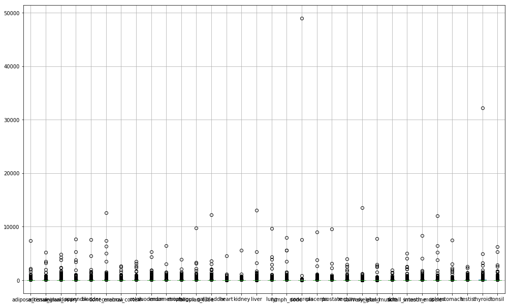

```python
# Aumentar o tamanho do plot na proporção 8/13
x_size = 17
y_size = x_size * (8/13)
plt.figure(figsize=(x_size, y_size))
# Aumentar o tamanho do plot na proporção 8/13
dataset.boxplot()
```

### Detectamos *outliers*, logo faz-se necessário um ajuste na escala

```python
from sklearn.preprocessing import RobustScaler
transformer = RobustScaler().fit(dataset[dataset.columns[:-1]])
```

```python
import numpy as np
a = np.array(dataset[dataset.columns[:-1]])
```

```python
df = pd.DataFrame(transformer.transform(a))
```

### Visualizando o boxplot depois de ter sua escala reajustada, percebe-se a presença de um *outlier* na coluna 18...

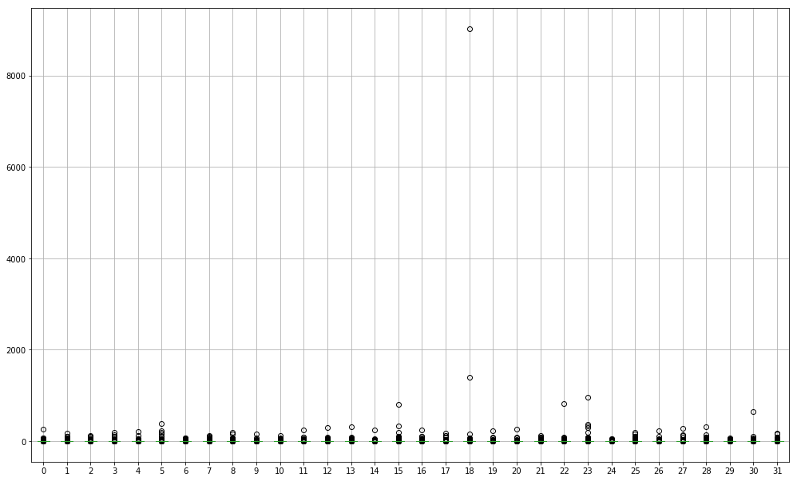

```python
# Aumentar o tamanho do plot na proporção 8/13
x_size = 17
y_size = x_size * (8/13)
plt.figure(figsize=(x_size, y_size))
# Aumentar o tamanho do plot na proporção 8/13
df.boxplot()
```

### Tentando localizar a instância com um valor acima de 9000

```python
a = df.loc[df[18] > 9000]
```

```python
a
```

|  | 0 | 1 | 2 | 3 | 4 | 5 | 6 | 7 | 8 | 9 | 10 | 11 | 12 | 13 | 14 | 15 | 16 | 17 | 18 | 19 | 20 | 21 | 22 | 23 | 24 | 25 | 26 | 27 | 28 | … |
| --- | --- | --- | --- | --- | --- | --- | --- | --- | --- | --- | --- | --- | --- | --- | --- | --- | --- | --- | --- | --- | --- | --- | --- | --- | --- | --- | --- | --- | --- | --- |
| 1940 | -0.377778 | -0.5 | 0.490196 | -0.5 | -0.59 | -0.283019 | -0.555555 | -0.49 | 0.2 | -0.478049 | -0.444444 | -0.58 | -0.5 | 0.15873 | -0.444444 | -0.357143 | -0.58 | -0.408333 | 9029.629629 | 0.4 | -0.49 | -0.5 | 0.655738 | -0.236842 | -0.45 | -0.111111 | -0.544444 | -0.416667 | -0.375 | … |

```python
aux = np.array(df[18])
```

### Substituindo o valor desse *outlier* pela mediana da coluna 18 do dataset

```python
df[18] = df[18].replace(9029.629629, np.nanmedian(aux))
```

# Identificando o número de classes

```python
class_array = dataset.iloc[:, 32]
```

### Significa que existem 2000 classes, ou seja, uma para cada instância.

```python
class_array.describe()
```

```
count                   2000
unique                  2000
top       b'ENSG00000008226'
freq                       1
Name: class, dtype: object
```

```python
a = np.array(class_array.value_counts())
```

```python
a.sum()
```

```
2000
```

# 1. Execução dos algoritmos de aprendizagem de máquina K-means e Hierárquico para resolver um problema de agrupamento

Execute os algoritmos de agrupamento K-means e Hierárquico com os seguintes valores de K: 2, 5, 10 e 100. Compare os agrupamentos resultantes dos 2 algoritmos.

### Separando as entradas do problema na variável X e a saída esperada do problema na variável y

```python
X = dataset.iloc[:, :-1].values
y = dataset.iloc[:, 32].values
```

## K-means, K = 2

```python
from sklearn.cluster import KMeans
kmeans = KMeans(n_clusters=2, random_state=0).fit(X)
```

```python
a = np.array(kmeans.labels_)
a.sum()
```

```
1
```

### Perceba que a soma da quantidade de rótulos foi igual a 1 devido ao *outlier* na coluna `"pancreas"` que causou um desbalanceamento nas classes

```python
unique, counts = np.unique(a, return_counts=True)
dicionario = dict(zip(unique, counts))
print(dicionario)
lista = list(dicionario.items())
class_instances = pd.DataFrame(lista, columns=["Classe", "Nº Instancias"])
class_instances
```

```
{0: 1999, 1: 1}
```

|  | Classe | Nº Instancias |
| --- | --- | --- |
| 0 | 0 | 1999 |
| 1 | 1 | 1 |

```python
kmeans.cluster_centers_[0]
```

```
array([39.05873463, 41.50708976, 51.34443912, 52.58058144, 48.95703592,
       53.87901696, 45.82057733, 40.68338489, 39.64275479, 52.09186528,
       41.51463154, 53.7184383 , 57.05223534, 21.9219698 , 27.74248304,
       35.80803475, 54.89160398, 54.32108966, 10.60767637, 52.11302411,
       46.41263207, 42.39812701, 27.63319137, 22.06430544, 35.27414936,
       43.41256626, 52.21187541, 56.19078705, 37.60317633, 44.49328609,
       72.77326733, 46.16636715])
```

### Isso é confirmado pois é possível ver que ele foi capturado no `kmeans.cluster_centers_[1]` (valor 4.89e+4)

```python
kmeans.cluster_centers_[1]
```

```
array([1.90384068e+00, 3.10531000e-06, 3.92502851e+01, 1.77945050e+00,
       3.54371895e-01, 3.14336000e-06, 3.81577000e-06, 3.07113403e-01,
       1.93553711e+01, 4.24481333e-01, 3.50664000e-06, 7.89698174e-01,
       4.07388000e-06, 8.96600403e+00, 2.49216000e-06, 2.92524000e-06,
       7.81259703e-01, 3.75191271e-01, 4.89701797e+04, 3.71545526e+01,
       3.57526536e-01, 3.09421000e-06, 1.87757351e+01, 2.13617917e-01,
       1.65234951e+00, 1.19679527e+01, 4.24842730e-01, 3.67851788e+00,
       5.87402703e+00, 2.79919837e+00, 4.58013000e-06, 3.17472000e-06])
```

### Adicionando a coluna calculada `kmeans.label_` ao conjunto de dados

```python
dataset["K-classes"] = kmeans.labels_
```

### Provado que a única instância da classe 1 que contém o valor com *outlier*, ou seja, o *outilier* interfere diretamente na análise de dados.

```python
dataset.loc[ dataset["pancreas"] > 40000]
```

|  | adipose_tissue | adrenal_gland | animal_ovary | appendix | bladder | bone_marrow | cerebral_cortex | colon | duodenum | endometrium | esophagus | fallopian_tube | gallbladder | heart | kidney | liver | lung | lymph_node | pancreas | placenta | prostate | rectum | salivary_gland | skeletal_muscle | skin | small_intestine | smooth_muscle | spleen | stomach | … |
| --- | --- | --- | --- | --- | --- | --- | --- | --- | --- | --- | --- | --- | --- | --- | --- | --- | --- | --- | --- | --- | --- | --- | --- | --- | --- | --- | --- | --- | --- | --- |
| 1940 | 1.903841 | 0.000003 | 39.250285 | 1.77945 | 0.354372 | 0.000003 | 0.000004 | 0.307113 | 19.355371 | 0.424481 | 0.000004 | 0.789698 | 0.000004 | 8.966004 | 0.000002 | 0.000003 | 0.78126 | 0.375191 | 48970.17971 | 37.154553 | 0.357527 | 0.000003 | 18.775735 | 0.213618 | 1.65235 | 11.967953 | 0.424843 | 3.678518 | 5.874027 | … |

## K-means, K = 5

```python
from sklearn.cluster import KMeans
kmeans = KMeans(n_clusters=5, random_state=0).fit(X)
```

```python
a = np.array(kmeans.labels_)
```

```python
unique, counts = np.unique(a, return_counts=True)
dicionario = dict(zip(unique, counts))
print(dicionario)
lista = list(dicionario.items())
class_instances = pd.DataFrame(lista, columns=["Classe", "Nº Instancias"])
class_instances
```

```
{0: 1995, 1: 1, 2: 2, 3: 1, 4: 1}
```

|  | Classe | Nº Instancias |
| --- | --- | --- |
| 0 | 0 | 1995 |
| 1 | 1 | 1 |
| 2 | 2 | 2 |
| 3 | 3 | 1 |
| 4 | 4 | 1 |

### A quantidade de instâncias de cada classe afetou diretamente na classificação das classes, devido ao número de *outliers* nas amostras.

### Adicionando a coluna calculada `kmeans.label_` ao conjunto de dados

```python
dataset["K-classes"] = kmeans.labels_
```

```python
dataset.loc[dataset["K-classes"] > 0]
```

|  | adipose_tissue | adrenal_gland | animal_ovary | appendix | bladder | bone_marrow | cerebral_cortex | colon | duodenum | endometrium | esophagus | fallopian_tube | gallbladder | heart | kidney | liver | lung | lymph_node | pancreas | placenta | prostate | rectum | salivary_gland | skeletal_muscle | skin | small_intestine | smooth_muscle | spleen | stomach | … |
| --- | --- | --- | --- | --- | --- | --- | --- | --- | --- | --- | --- | --- | --- | --- | --- | --- | --- | --- | --- | --- | --- | --- | --- | --- | --- | --- | --- | --- | --- | --- |
| 591 | 0.317307 | 1.863187 | 0.000004 | 0.711780 | 0.708744 | 0.628672 | 0.381577 | 0.307113 | 0.000003 | 0.000004 | 0.350664 | 0.394849 | 0.814776 | 6.724503 | 1.246079 | 0.000003 | 0.390630 | 26.263389 | 0.000002 | 0.412828 | 0.715053 | 0.309421 | 1.341124 | 0.000002 | 2.313289 | 0.000003 | 0.424843 | 0.367852 | 0.000003 | … |
| 1315 | 2027.590321 | 1400.495332 | 2296.141680 | 7644.519332 | 4514.697940 | 3463.984873 | 2430.647195 | 2346.346398 | 1800.049515 | 6460.605882 | 3857.301972 | 3293.041385 | 3637.973632 | 428.126692 | 799.982414 | 1292.954824 | 4394.585827 | 7931.543465 | 188.802629 | 3798.020932 | 3128.357190 | 2558.912879 | 992.431712 | 183.711409 | 1391.278291 | 2600.037730 | 8322.669088 | 5201.424283 | 2232.130272 | … |
| 1718 | 7377.382624 | 3490.369741 | 4827.785071 | 5295.644677 | 7548.121360 | 6349.591147 | 1938.412520 | 3095.703101 | 4330.073027 | 2996.838208 | 2114.502808 | 3158.792695 | 12201.266550 | 1187.995534 | 5587.416115 | 5344.408289 | 9707.151804 | 5612.861412 | 843.586214 | 9032.684565 | 2288.169831 | 3945.119614 | 1166.777824 | 324.699234 | 1311.965514 | 5032.524122 | 4112.477630 | 12036.110500 | 3072.116138 | … |
| 1874 | 28.557610 | 46.579667 | 54.950399 | 1854.187417 | 836.317672 | 12623.741610 | 19.078863 | 546.661857 | 5275.721159 | 114.609960 | 199.878375 | 110.557744 | 3055.408986 | 26.898012 | 32.398042 | 125.785198 | 2179.714570 | 1485.757432 | 18.076847 | 202.285898 | 60.779511 | 519.827526 | 13529.258260 | 2.136179 | 99.140971 | 2058.487869 | 195.427656 | 1364.730134 | 7486.447452 | … |
| 1940 | 1.903841 | 0.000003 | 39.250285 | 1.779450 | 0.354372 | 0.000003 | 0.000004 | 0.307113 | 19.355371 | 0.424481 | 0.000004 | 0.789698 | 0.000004 | 8.966004 | 0.000002 | 0.000003 | 0.781260 | 0.375191 | 48970.179710 | 37.154553 | 0.357527 | 0.000003 | 18.775735 | 0.213618 | 1.652350 | 11.967953 | 0.424843 | 3.678518 | 5.874027 | … |

### Acima podemos ver as instâncias que pertencem às demais classes. Em cada uma delas existe um *outlier* que altera o comportamento do algoritmo.

## K-means, K = 10

```python
from sklearn.cluster import KMeans
kmeans = KMeans(n_clusters=10, random_state=0).fit(X)
```

```python
a = np.array(kmeans.labels_)
```

```python
unique, counts = np.unique(a, return_counts=True)
dicionario = dict(zip(unique, counts))
print(dicionario)
lista = list(dicionario.items())
class_instances = pd.DataFrame(lista, columns=["Classe", "Nº Instancias"])
class_instances
```

```
{0: 1925, 1: 1, 2: 1, 3: 1, 4: 1, 5: 1, 6: 66, 7: 1, 8: 2, 9: 1}
```

|  | Classe | Nº Instancias |
| --- | --- | --- |
| 0 | 0 | 1925 |
| 1 | 1 | 1 |
| 2 | 2 | 1 |
| 3 | 3 | 1 |
| 4 | 4 | 1 |
| 5 | 5 | 1 |
| 6 | 6 | 66 |
| 7 | 7 | 1 |
| 8 | 8 | 2 |
| 9 | 9 | 1 |

### Podemos perceber uma melhoria, com a classe 6 possuindo 66 instâncias, mas pode ser que todas elas sejam *outliers*.

### Adicionando a coluna calculada `kmeans.label_` ao conjunto de dados

```python
dataset["K-classes"] = kmeans.labels_
```

```python
dataset.loc[(dataset["K-classes"] > 0) & (dataset["K-classes"] != 6)]
```

|  | adipose_tissue | adrenal_gland | animal_ovary | appendix | bladder | bone_marrow | cerebral_cortex | colon | duodenum | endometrium | esophagus | fallopian_tube | gallbladder | heart | kidney | liver | lung | lymph_node | pancreas | placenta | prostate | rectum | salivary_gland | skeletal_muscle | skin | small_intestine | smooth_muscle | spleen | stomach | … |
| --- | --- | --- | --- | --- | --- | --- | --- | --- | --- | --- | --- | --- | --- | --- | --- | --- | --- | --- | --- | --- | --- | --- | --- | --- | --- | --- | --- | --- | --- | --- |
| 393 | 621.921288 | 586.903809 | 726.130275 | 3459.251765 | 1998.657487 | 644.389201 | 450.261176 | 786.210311 | 1476.538312 | 827.738599 | 511.969171 | 1772.872400 | 2049.160960 | 179.320080 | 453.572584 | 532.393163 | 3921.923707 | 5612.861412 | 70.298851 | 346.775824 | 507.687681 | 1079.879800 | 565.954301 | 66.221554 | 591.541126 | 2133.287574 | 1291.521900 | 6463.155915 | 1527.247028 | … |
| 510 | 2138.647694 | 794.959656 | 3768.027372 | 3800.906260 | 1587.586089 | 1518.243824 | 2663.409328 | 3528.732999 | 1139.201844 | 1073.937771 | 999.391875 | 1113.474425 | 1861.762542 | 342.949654 | 495.939254 | 476.813657 | 2925.817586 | 3549.309422 | 148.631857 | 2613.203533 | 793.708910 | 2558.912879 | 482.804617 | 123.898392 | 343.688699 | 2456.422297 | 1797.084749 | 3833.015631 | 1715.215893 | … |
| 591 | 0.317307 | 1.863187 | 0.000004 | 0.711780 | 0.708744 | 0.628672 | 0.381577 | 0.307113 | 0.000003 | 0.000004 | 0.350664 | 0.394849 | 0.814776 | 6.724503 | 1.246079 | 0.000003 | 0.390630 | 26.263389 | 0.000002 | 0.412828 | 0.715053 | 0.309421 | 1.341124 | 0.000002 | 2.313289 | 0.000003 | 0.424843 | 0.367852 | 0.000003 | … |
| 1315 | 2027.590321 | 1400.495332 | 2296.141680 | 7644.519332 | 4514.697940 | 3463.984873 | 2430.647195 | 2346.346398 | 1800.049515 | 6460.605882 | 3857.301972 | 3293.041385 | 3637.973632 | 428.126692 | 799.982414 | 1292.954824 | 4394.585827 | 7931.543465 | 188.802629 | 3798.020932 | 3128.357190 | 2558.912879 | 992.431712 | 183.711409 | 1391.278291 | 2600.037730 | 8322.669088 | 5201.424283 | 2232.130272 | … |
| 1657 | 1.903841 | 1.552656 | 3.925029 | 2.847121 | 3.543719 | 3.143362 | 3.815773 | 2.764021 | 2.488548 | 16.979253 | 2.805311 | 9733.029992 | 4.073879 | 0.672450 | 2.492157 | 5.850474 | 3.906299 | 7.503825 | 0.200854 | 8.256567 | 7.150531 | 6.188423 | 2.145798 | 1.068090 | 9.914097 | 2.094392 | 4.248427 | 3.678518 | 2.643312 | … |
| 1718 | 7377.382624 | 3490.369741 | 4827.785071 | 5295.644677 | 7548.121360 | 6349.591147 | 1938.412520 | 3095.703101 | 4330.073027 | 2996.838208 | 2114.502808 | 3158.792695 | 12201.266550 | 1187.995534 | 5587.416115 | 5344.408289 | 9707.151804 | 5612.861412 | 843.586214 | 9032.684565 | 2288.169831 | 3945.119614 | 1166.777824 | 324.699234 | 1311.965514 | 5032.524122 | 4112.477630 | 12036.110500 | 3072.116138 | … |
| 1874 | 28.557610 | 46.579667 | 54.950399 | 1854.187417 | 836.317672 | 12623.741610 | 19.078863 | 546.661857 | 5275.721159 | 114.609960 | 199.878375 | 110.557744 | 3055.408986 | 26.898012 | 32.398042 | 125.785198 | 2179.714570 | 1485.757432 | 18.076847 | 202.285898 | 60.779511 | 519.827526 | 13529.258260 | 2.136179 | 99.140971 | 2058.487869 | 195.427656 | 1364.730134 | 7486.447452 | … |
| 1933 | 0.317307 | 0.000003 | 0.000004 | 0.000004 | 0.000004 | 0.000003 | 0.000004 | 1.228454 | 2.765053 | 0.000004 | 0.000004 | 0.789698 | 8.147757 | 0.000002 | 34.890199 | 13058.258680 | 15.625194 | 0.000004 | 4.017077 | 0.000004 | 0.000004 | 0.928263 | 0.000003 | 0.000002 | 0.000003 | 1.196795 | 0.000004 | 0.000004 | 5.874027 | … |
| 1940 | 1.903841 | 0.000003 | 39.250285 | 1.779450 | 0.354372 | 0.000003 | 0.000004 | 0.307113 | 19.355371 | 0.424481 | 0.000004 | 0.789698 | 0.000004 | 8.966004 | 0.000002 | 0.000003 | 0.781260 | 0.375191 | 48970.179710 | 37.154553 | 0.357527 | 0.000003 | 18.775735 | 0.213618 | 1.652350 | 11.967953 | 0.424843 | 3.678518 | 5.874027 | … |

## K-means, K = 100

```python
from sklearn.cluster import KMeans
kmeans = KMeans(n_clusters=100, random_state=0).fit(X)
```

```python
a = np.array(kmeans.labels_)
```

```python
unique, counts = np.unique(a, return_counts=True)
dicionario = dict(zip(unique, counts))
print(dicionario)
lista = list(dicionario.items())
class_instances = pd.DataFrame(lista, columns=["Classe", "Nº Instancias"])
class_instances
```

```
{0: 38, 1: 1, 2: 1, 3: 1, 4: 1, 5: 1, 6: 1, 7: 1, 8: 1, 9: 1, 10: 1, 11: 1, 12: 1, 13: 1, 14: 1, 15: 1, 16: 86, 17: 1, 18: 1, 19: 1, 20: 1, 21: 1, 22: 13, 23: 1, 24: 2, 25: 1, 26: 1, 27: 1, 28: 1, 29: 4, 30: 24, 31: 2, 32: 3, 33: 1, 34: 1, 35: 1, 36: 1, 37: 1, 38: 448, 39: 1, 40: 1, 41: 1, 42: 1, 43…
```

|  | Classe | Nº Instancias |
| --- | --- | --- |
| 0 | 0 | 38 |
| 1 | 1 | 1 |
| 2 | 2 | 1 |
| 3 | 3 | 1 |
| 4 | 4 | 1 |
| 5 | 5 | 1 |
| 6 | 6 | 1 |
| 7 | 7 | 1 |
| 8 | 8 | 1 |
| 9 | 9 | 1 |
| 10 | 10 | 1 |
| 11 | 11 | 1 |
| 12 | 12 | 1 |
| 13 | 13 | 1 |
| 14 | 14 | 1 |
| 15 | 15 | 1 |
| 16 | 16 | 86 |
| 17 | 17 | 1 |
| 18 | 18 | 1 |
| 19 | 19 | 1 |
| 20 | 20 | 1 |
| 21 | 21 | 1 |
| 22 | 22 | 13 |
| 23 | 23 | 1 |
| 24 | 24 | 2 |
| 25 | 25 | 1 |
| 26 | 26 | 1 |
| 27 | 27 | 1 |
| 28 | 28 | 1 |
| 29 | 29 | 4 |
| ... | ... | ... |
| 70 | 70 | 2 |
| 71 | 71 | 1 |
| 72 | 72 | 47 |
| 73 | 73 | 12 |
| 74 | 74 | 4 |
| 75 | 75 | 1 |
| 76 | 76 | 8 |
| 77 | 77 | 2 |
| 78 | 78 | 1 |
| 79 | 79 | 160 |
| 80 | 80 | 1 |
| 81 | 81 | 15 |
| 82 | 82 | 8 |
| 83 | 83 | 1 |
| 84 | 84 | 1 |
| 85 | 85 | 1 |
| 86 | 86 | 1 |
| 87 | 87 | 1 |
| 88 | 88 | 5 |
| 89 | 89 | 25 |
| 90 | 90 | 7 |
| 91 | 91 | 300 |
| 92 | 92 | 13 |
| 93 | 93 | 1 |
| 94 | 94 | 1 |
| 95 | 95 | 28 |
| 96 | 96 | 1 |
| 97 | 97 | 1 |
| 98 | 98 | 3 |
| 99 | 99 | 1 |

100 rows × 2 columns

### Observando quais classes possuem mais de 10 instâncias...

```python
class_instances.loc[class_instances["Nº Instancias"] > 10]
```

|  | Classe | Nº Instancias |
| --- | --- | --- |
| 0 | 0 | 38 |
| 16 | 16 | 86 |
| 22 | 22 | 13 |
| 30 | 30 | 24 |
| 38 | 38 | 448 |
| 43 | 43 | 73 |
| 55 | 55 | 519 |
| 60 | 60 | 22 |
| 72 | 72 | 47 |
| 73 | 73 | 12 |
| 79 | 79 | 160 |
| 81 | 81 | 15 |
| 89 | 89 | 25 |
| 91 | 91 | 300 |
| 92 | 92 | 13 |
| 95 | 95 | 28 |

##### É possível perceber que o número de instâncias em algumas classes aumentou consideravelmente. Isso pode ser explicado pelo fato de que existem mais classes a serem alocadas, logo, os *outliers* podem ficar em classes individuais sem atrapalhar tanto o algoritmo como acontecia com as outras classes para um k menor.

### Adicionando a coluna calculada `kmeans.label_` ao conjunto de dados

```python
dataset["K-classes"] = kmeans.labels_
```

```python
dataset.loc[ dataset["pancreas"] > 40000]
```

|  | adipose_tissue | adrenal_gland | animal_ovary | appendix | bladder | bone_marrow | cerebral_cortex | colon | duodenum | endometrium | esophagus | fallopian_tube | gallbladder | heart | kidney | liver | lung | lymph_node | pancreas | placenta | prostate | rectum | salivary_gland | skeletal_muscle | skin | small_intestine | smooth_muscle | spleen | stomach | … |
| --- | --- | --- | --- | --- | --- | --- | --- | --- | --- | --- | --- | --- | --- | --- | --- | --- | --- | --- | --- | --- | --- | --- | --- | --- | --- | --- | --- | --- | --- | --- |
| 1940 | 1.903841 | 0.000003 | 39.250285 | 1.77945 | 0.354372 | 0.000003 | 0.000004 | 0.307113 | 19.355371 | 0.424481 | 0.000004 | 0.789698 | 0.000004 | 8.966004 | 0.000002 | 0.000003 | 0.78126 | 0.375191 | 48970.17971 | 37.154553 | 0.357527 | 0.000003 | 18.775735 | 0.213618 | 1.65235 | 11.967953 | 0.424843 | 3.678518 | 5.874027 | … |

## Hierárquico, K = 2

```python
from sklearn.cluster import AgglomerativeClustering
clustering = AgglomerativeClustering(n_clusters=2, affinity='euclidean', linkage="ward").fit(X)
```

```python
a = np.array(clustering.labels_)
```

```python
unique, counts = np.unique(a, return_counts=True)
dicionario = dict(zip(unique, counts))
print(dicionario)
lista = list(dicionario.items())
class_instances = pd.DataFrame(lista, columns=["Classe", "Nº Instancias"])
class_instances
```

```
{0: 1999, 1: 1}
```

|  | Classe | Nº Instancias |
| --- | --- | --- |
| 0 | 0 | 1999 |
| 1 | 1 | 1 |

```python
dataset.drop("K-classes", axis=1, inplace=True)
```

```python
dataset["K-classes-hierar"] = clustering.labels_
```

```python
dataset.loc[ dataset["pancreas"] > 40000]
```

|  | adipose_tissue | adrenal_gland | animal_ovary | appendix | bladder | bone_marrow | cerebral_cortex | colon | duodenum | endometrium | esophagus | fallopian_tube | gallbladder | heart | kidney | liver | lung | lymph_node | pancreas | placenta | prostate | rectum | salivary_gland | skeletal_muscle | skin | small_intestine | smooth_muscle | spleen | stomach | … |
| --- | --- | --- | --- | --- | --- | --- | --- | --- | --- | --- | --- | --- | --- | --- | --- | --- | --- | --- | --- | --- | --- | --- | --- | --- | --- | --- | --- | --- | --- | --- |
| 1940 | 1.903841 | 0.000003 | 39.250285 | 1.77945 | 0.354372 | 0.000003 | 0.000004 | 0.307113 | 19.355371 | 0.424481 | 0.000004 | 0.789698 | 0.000004 | 8.966004 | 0.000002 | 0.000003 | 0.78126 | 0.375191 | 48970.17971 | 37.154553 | 0.357527 | 0.000003 | 18.775735 | 0.213618 | 1.65235 | 11.967953 | 0.424843 | 3.678518 | 5.874027 | … |

## Hierárquico, K = 5

```python
from sklearn.cluster import AgglomerativeClustering
clustering = AgglomerativeClustering(n_clusters=5, affinity='euclidean', linkage="ward").fit(X)
```

```python
a = np.array(clustering.labels_)
```

### Percebemos que a classe 2 possui muitas instâncias quando comparamos com as outras classes, o que caracteriza um desbalanceamento de classes. Com o desbalanceamento, isto prejudica significativamente a classificação do algoritmo e separação em grupos.

```python
unique, counts = np.unique(a, return_counts=True)
dicionario = dict(zip(unique, counts))
print(dicionario)
lista = list(dicionario.items())
class_instances = pd.DataFrame(lista, columns=["Classe", "Nº Instancias"])
class_instances
```

```
{0: 4, 1: 1, 2: 1993, 3: 1, 4: 1}
```

|  | Classe | Nº Instancias |
| --- | --- | --- |
| 0 | 0 | 4 |
| 1 | 1 | 1 |
| 2 | 2 | 1993 |
| 3 | 3 | 1 |
| 4 | 4 | 1 |

```python
dataset["K-classes-hierar"] = clustering.labels_
```

```python
dataset.loc[dataset["K-classes-hierar"] != 2]
```

|  | adipose_tissue | adrenal_gland | animal_ovary | appendix | bladder | bone_marrow | cerebral_cortex | colon | duodenum | endometrium | esophagus | fallopian_tube | gallbladder | heart | kidney | liver | lung | lymph_node | pancreas | placenta | prostate | rectum | salivary_gland | skeletal_muscle | skin | small_intestine | smooth_muscle | spleen | stomach | … |
| --- | --- | --- | --- | --- | --- | --- | --- | --- | --- | --- | --- | --- | --- | --- | --- | --- | --- | --- | --- | --- | --- | --- | --- | --- | --- | --- | --- | --- | --- | --- |
| 393 | 621.921288 | 586.903809 | 726.130275 | 3459.251765 | 1998.657487 | 644.389201 | 450.261176 | 786.210311 | 1476.538312 | 827.738599 | 511.969171 | 1772.872400 | 2049.160960 | 179.320080 | 453.572584 | 532.393163 | 3921.923707 | 5612.861412 | 70.298851 | 346.775824 | 507.687681 | 1079.879800 | 565.954301 | 66.221554 | 591.541126 | 2133.287574 | 1291.521900 | 6463.155915 | 1527.247028 | … |
| 510 | 2138.647694 | 794.959656 | 3768.027372 | 3800.906260 | 1587.586089 | 1518.243824 | 2663.409328 | 3528.732999 | 1139.201844 | 1073.937771 | 999.391875 | 1113.474425 | 1861.762542 | 342.949654 | 495.939254 | 476.813657 | 2925.817586 | 3549.309422 | 148.631857 | 2613.203533 | 793.708910 | 2558.912879 | 482.804617 | 123.898392 | 343.688699 | 2456.422297 | 1797.084749 | 3833.015631 | 1715.215893 | … |
| 591 | 0.317307 | 1.863187 | 0.000004 | 0.711780 | 0.708744 | 0.628672 | 0.381577 | 0.307113 | 0.000003 | 0.000004 | 0.350664 | 0.394849 | 0.814776 | 6.724503 | 1.246079 | 0.000003 | 0.390630 | 26.263389 | 0.000002 | 0.412828 | 0.715053 | 0.309421 | 1.341124 | 0.000002 | 2.313289 | 0.000003 | 0.424843 | 0.367852 | 0.000003 | … |
| 1315 | 2027.590321 | 1400.495332 | 2296.141680 | 7644.519332 | 4514.697940 | 3463.984873 | 2430.647195 | 2346.346398 | 1800.049515 | 6460.605882 | 3857.301972 | 3293.041385 | 3637.973632 | 428.126692 | 799.982414 | 1292.954824 | 4394.585827 | 7931.543465 | 188.802629 | 3798.020932 | 3128.357190 | 2558.912879 | 992.431712 | 183.711409 | 1391.278291 | 2600.037730 | 8322.669088 | 5201.424283 | 2232.130272 | … |
| 1718 | 7377.382624 | 3490.369741 | 4827.785071 | 5295.644677 | 7548.121360 | 6349.591147 | 1938.412520 | 3095.703101 | 4330.073027 | 2996.838208 | 2114.502808 | 3158.792695 | 12201.266550 | 1187.995534 | 5587.416115 | 5344.408289 | 9707.151804 | 5612.861412 | 843.586214 | 9032.684565 | 2288.169831 | 3945.119614 | 1166.777824 | 324.699234 | 1311.965514 | 5032.524122 | 4112.477630 | 12036.110500 | 3072.116138 | … |
| 1874 | 28.557610 | 46.579667 | 54.950399 | 1854.187417 | 836.317672 | 12623.741610 | 19.078863 | 546.661857 | 5275.721159 | 114.609960 | 199.878375 | 110.557744 | 3055.408986 | 26.898012 | 32.398042 | 125.785198 | 2179.714570 | 1485.757432 | 18.076847 | 202.285898 | 60.779511 | 519.827526 | 13529.258260 | 2.136179 | 99.140971 | 2058.487869 | 195.427656 | 1364.730134 | 7486.447452 | … |
| 1940 | 1.903841 | 0.000003 | 39.250285 | 1.779450 | 0.354372 | 0.000003 | 0.000004 | 0.307113 | 19.355371 | 0.424481 | 0.000004 | 0.789698 | 0.000004 | 8.966004 | 0.000002 | 0.000003 | 0.781260 | 0.375191 | 48970.179710 | 37.154553 | 0.357527 | 0.000003 | 18.775735 | 0.213618 | 1.652350 | 11.967953 | 0.424843 | 3.678518 | 5.874027 | … |

## Hierárquico, K = 10

```python
from sklearn.cluster import AgglomerativeClustering
clustering = AgglomerativeClustering(n_clusters=10, affinity='euclidean', linkage="ward").fit(X)
```

```python
a = np.array(clustering.labels_)
```

```python
unique, counts = np.unique(a, return_counts=True)
dicionario = dict(zip(unique, counts))
print(dicionario)
lista = list(dicionario.items())
class_instances = pd.DataFrame(lista, columns=["Classe", "Nº Instancias"])
class_instances
```

```
{0: 60, 1: 1, 2: 1931, 3: 1, 4: 1, 5: 1, 6: 2, 7: 1, 8: 1, 9: 1}
```

|  | Classe | Nº Instancias |
| --- | --- | --- |
| 0 | 0 | 60 |
| 1 | 1 | 1 |
| 2 | 2 | 1931 |
| 3 | 3 | 1 |
| 4 | 4 | 1 |
| 5 | 5 | 1 |
| 6 | 6 | 2 |
| 7 | 7 | 1 |
| 8 | 8 | 1 |
| 9 | 9 | 1 |

```python
dataset["K-classes-hierar"] = clustering.labels_
```

```python
dataset.loc[(dataset["K-classes-hierar"] != 2) & (dataset["K-classes-hierar"] != 0)]
```

|  | adipose_tissue | adrenal_gland | animal_ovary | appendix | bladder | bone_marrow | cerebral_cortex | colon | duodenum | endometrium | esophagus | fallopian_tube | gallbladder | heart | kidney | liver | lung | lymph_node | pancreas | placenta | prostate | rectum | salivary_gland | skeletal_muscle | skin | small_intestine | smooth_muscle | spleen | stomach | … |
| --- | --- | --- | --- | --- | --- | --- | --- | --- | --- | --- | --- | --- | --- | --- | --- | --- | --- | --- | --- | --- | --- | --- | --- | --- | --- | --- | --- | --- | --- | --- |
| 393 | 621.921288 | 586.903809 | 726.130275 | 3459.251765 | 1998.657487 | 644.389201 | 450.261176 | 786.210311 | 1476.538312 | 827.738599 | 511.969171 | 1772.872400 | 2049.160960 | 179.320080 | 453.572584 | 532.393163 | 3921.923707 | 5612.861412 | 70.298851 | 346.775824 | 507.687681 | 1079.879800 | 565.954301 | 66.221554 | 591.541126 | 2133.287574 | 1291.521900 | 6463.155915 | 1527.247028 | … |
| 510 | 2138.647694 | 794.959656 | 3768.027372 | 3800.906260 | 1587.586089 | 1518.243824 | 2663.409328 | 3528.732999 | 1139.201844 | 1073.937771 | 999.391875 | 1113.474425 | 1861.762542 | 342.949654 | 495.939254 | 476.813657 | 2925.817586 | 3549.309422 | 148.631857 | 2613.203533 | 793.708910 | 2558.912879 | 482.804617 | 123.898392 | 343.688699 | 2456.422297 | 1797.084749 | 3833.015631 | 1715.215893 | … |
| 591 | 0.317307 | 1.863187 | 0.000004 | 0.711780 | 0.708744 | 0.628672 | 0.381577 | 0.307113 | 0.000003 | 0.000004 | 0.350664 | 0.394849 | 0.814776 | 6.724503 | 1.246079 | 0.000003 | 0.390630 | 26.263389 | 0.000002 | 0.412828 | 0.715053 | 0.309421 | 1.341124 | 0.000002 | 2.313289 | 0.000003 | 0.424843 | 0.367852 | 0.000003 | … |
| 1315 | 2027.590321 | 1400.495332 | 2296.141680 | 7644.519332 | 4514.697940 | 3463.984873 | 2430.647195 | 2346.346398 | 1800.049515 | 6460.605882 | 3857.301972 | 3293.041385 | 3637.973632 | 428.126692 | 799.982414 | 1292.954824 | 4394.585827 | 7931.543465 | 188.802629 | 3798.020932 | 3128.357190 | 2558.912879 | 992.431712 | 183.711409 | 1391.278291 | 2600.037730 | 8322.669088 | 5201.424283 | 2232.130272 | … |
| 1657 | 1.903841 | 1.552656 | 3.925029 | 2.847121 | 3.543719 | 3.143362 | 3.815773 | 2.764021 | 2.488548 | 16.979253 | 2.805311 | 9733.029992 | 4.073879 | 0.672450 | 2.492157 | 5.850474 | 3.906299 | 7.503825 | 0.200854 | 8.256567 | 7.150531 | 6.188423 | 2.145798 | 1.068090 | 9.914097 | 2.094392 | 4.248427 | 3.678518 | 2.643312 | … |
| 1718 | 7377.382624 | 3490.369741 | 4827.785071 | 5295.644677 | 7548.121360 | 6349.591147 | 1938.412520 | 3095.703101 | 4330.073027 | 2996.838208 | 2114.502808 | 3158.792695 | 12201.266550 | 1187.995534 | 5587.416115 | 5344.408289 | 9707.151804 | 5612.861412 | 843.586214 | 9032.684565 | 2288.169831 | 3945.119614 | 1166.777824 | 324.699234 | 1311.965514 | 5032.524122 | 4112.477630 | 12036.110500 | 3072.116138 | … |
| 1874 | 28.557610 | 46.579667 | 54.950399 | 1854.187417 | 836.317672 | 12623.741610 | 19.078863 | 546.661857 | 5275.721159 | 114.609960 | 199.878375 | 110.557744 | 3055.408986 | 26.898012 | 32.398042 | 125.785198 | 2179.714570 | 1485.757432 | 18.076847 | 202.285898 | 60.779511 | 519.827526 | 13529.258260 | 2.136179 | 99.140971 | 2058.487869 | 195.427656 | 1364.730134 | 7486.447452 | … |
| 1933 | 0.317307 | 0.000003 | 0.000004 | 0.000004 | 0.000004 | 0.000003 | 0.000004 | 1.228454 | 2.765053 | 0.000004 | 0.000004 | 0.789698 | 8.147757 | 0.000002 | 34.890199 | 13058.258680 | 15.625194 | 0.000004 | 4.017077 | 0.000004 | 0.000004 | 0.928263 | 0.000003 | 0.000002 | 0.000003 | 1.196795 | 0.000004 | 0.000004 | 5.874027 | … |
| 1940 | 1.903841 | 0.000003 | 39.250285 | 1.779450 | 0.354372 | 0.000003 | 0.000004 | 0.307113 | 19.355371 | 0.424481 | 0.000004 | 0.789698 | 0.000004 | 8.966004 | 0.000002 | 0.000003 | 0.781260 | 0.375191 | 48970.179710 | 37.154553 | 0.357527 | 0.000003 | 18.775735 | 0.213618 | 1.652350 | 11.967953 | 0.424843 | 3.678518 | 5.874027 | … |

## Hierárquico, K = 100

```python
from sklearn.cluster import AgglomerativeClustering
clustering = AgglomerativeClustering(n_clusters=100, affinity='euclidean', linkage="ward").fit(X)
```

```python
a = np.array(clustering.labels_)
```

```python
unique, counts = np.unique(a, return_counts=True)
dicionario = dict(zip(unique, counts))
print(dicionario)
lista = list(dicionario.items())
class_instances = pd.DataFrame(lista, columns=["Classe", "Nº Instancias"])
class_instances
```

```
{0: 564, 1: 2, 2: 10, 3: 28, 4: 10, 5: 12, 6: 8, 7: 6, 8: 4, 9: 69, 10: 9, 11: 34, 12: 5, 13: 2, 14: 2, 15: 2, 16: 15, 17: 3, 18: 13, 19: 17, 20: 333, 21: 8, 22: 2, 23: 320, 24: 2, 25: 1, 26: 1, 27: 2, 28: 2, 29: 60, 30: 1, 31: 1, 32: 1, 33: 3, 34: 20, 35: 1, 36: 2, 37: 1, 38: 4, 39: 1, 40: 19, 41: …
```

|  | Classe | Nº Instancias |
| --- | --- | --- |
| 0 | 0 | 564 |
| 1 | 1 | 2 |
| 2 | 2 | 10 |
| 3 | 3 | 28 |
| 4 | 4 | 10 |
| 5 | 5 | 12 |
| 6 | 6 | 8 |
| 7 | 7 | 6 |
| 8 | 8 | 4 |
| 9 | 9 | 69 |
| 10 | 10 | 9 |
| 11 | 11 | 34 |
| 12 | 12 | 5 |
| 13 | 13 | 2 |
| 14 | 14 | 2 |
| 15 | 15 | 2 |
| 16 | 16 | 15 |
| 17 | 17 | 3 |
| 18 | 18 | 13 |
| 19 | 19 | 17 |
| 20 | 20 | 333 |
| 21 | 21 | 8 |
| 22 | 22 | 2 |
| 23 | 23 | 320 |
| 24 | 24 | 2 |
| 25 | 25 | 1 |
| 26 | 26 | 1 |
| 27 | 27 | 2 |
| 28 | 28 | 2 |
| 29 | 29 | 60 |
| ... | ... | ... |
| 70 | 70 | 1 |
| 71 | 71 | 1 |
| 72 | 72 | 1 |
| 73 | 73 | 1 |
| 74 | 74 | 3 |
| 75 | 75 | 1 |
| 76 | 76 | 1 |
| 77 | 77 | 1 |
| 78 | 78 | 1 |
| 79 | 79 | 1 |
| 80 | 80 | 1 |
| 81 | 81 | 1 |
| 82 | 82 | 1 |
| 83 | 83 | 1 |
| 84 | 84 | 1 |
| 85 | 85 | 1 |
| 86 | 86 | 1 |
| 87 | 87 | 1 |
| 88 | 88 | 8 |
| 89 | 89 | 1 |
| 90 | 90 | 4 |
| 91 | 91 | 1 |
| 92 | 92 | 1 |
| 93 | 93 | 1 |
| 94 | 94 | 1 |
| 95 | 95 | 1 |
| 96 | 96 | 1 |
| 97 | 97 | 1 |
| 98 | 98 | 1 |
| 99 | 99 | 1 |

100 rows × 2 columns

### Com k = 100 percebemos que há uma diversidade maior de classes com mais de dez instâncias

```python
class_instances.loc[class_instances["Nº Instancias"] > 10]
```

|  | Classe | Nº Instancias |
| --- | --- | --- |
| 0 | 0 | 564 |
| 3 | 3 | 28 |
| 5 | 5 | 12 |
| 9 | 9 | 69 |
| 11 | 11 | 34 |
| 16 | 16 | 15 |
| 18 | 18 | 13 |
| 19 | 19 | 17 |
| 20 | 20 | 333 |
| 23 | 23 | 320 |
| 29 | 29 | 60 |
| 34 | 34 | 20 |
| 40 | 40 | 19 |
| 44 | 44 | 203 |
| 48 | 48 | 33 |
| 49 | 49 | 79 |

```python
dataset["K-classes-hierar"] = clustering.labels_
```

```python
dataset.describe()
```

|  | adipose_tissue | adrenal_gland | animal_ovary | appendix | bladder | bone_marrow | cerebral_cortex | colon | duodenum | endometrium | esophagus | fallopian_tube | gallbladder | heart | kidney | liver | lung | lymph_node | pancreas | placenta | prostate | rectum | salivary_gland | skeletal_muscle | skin | small_intestine | smooth_muscle | spleen | stomach | … |
| --- | --- | --- | --- | --- | --- | --- | --- | --- | --- | --- | --- | --- | --- | --- | --- | --- | --- | --- | --- | --- | --- | --- | --- | --- | --- | --- | --- | --- | --- | --- |
| count | 2000.000000 | 2000.000000 | 2000.000000 | 2000.000000 | 2000.000000 | 2000.000000 | 2000.000000 | 2000.000000 | 2000.000000 | 2000.000000 | 2000.000000 | 2000.000000 | 2000.000000 | 2000.000000 | 2000.000000 | 2000.000000 | 2000.000000 | 2000.000000 | 2000.000000 | 2000.000000 | 2000.000000 | 2000.000000 | 2000.000000 | 2000.000000 | 2000.000000 | 2000.000000 | 2000.000000 | 2000.000000 | 2000.000000 | … |
| mean | 39.040157 | 41.486336 | 51.338392 | 52.555181 | 48.932735 | 53.852077 | 45.797667 | 40.663197 | 39.632611 | 52.066032 | 41.493874 | 53.691974 | 57.023709 | 21.915492 | 27.728612 | 35.790131 | 54.864549 | 54.294117 | 35.087462 | 52.105545 | 46.389605 | 42.376928 | 27.628763 | 22.053380 | 35.257338 | 43.396844 | 52.185982 | 56.164531 | 37.587312 | … |
| std | 195.264717 | 181.466441 | 210.726346 | 252.295704 | 221.732356 | 393.758129 | 123.183344 | 157.028175 | 185.991398 | 186.169270 | 139.247221 | 261.725555 | 314.203534 | 116.726607 | 136.411996 | 336.523288 | 277.654367 | 277.993904 | 1108.114405 | 242.242244 | 241.613858 | 165.470468 | 308.543568 | 208.651352 | 95.223057 | 193.638153 | 233.848790 | 347.561819 | 207.009834 | … |
| min | 0.000003 | 0.000003 | 0.000004 | 0.000004 | 0.000004 | 0.000003 | 0.000004 | 0.000003 | 0.000003 | 0.000004 | 0.000004 | 0.000004 | 0.000004 | 0.000002 | 0.000002 | 0.000003 | 0.000004 | 0.000004 | 0.000002 | 0.000004 | 0.000004 | 0.000003 | 0.000003 | 0.000002 | 0.000003 | 0.000003 | 0.000004 | 0.000004 | 0.000003 | … |
| 25% | 3.173068 | 3.105311 | 3.140023 | 7.117802 | 7.087438 | 1.257345 | 7.631545 | 3.071134 | 2.765053 | 7.428423 | 3.506638 | 7.896982 | 8.147757 | 1.569051 | 2.492157 | 1.170095 | 7.812597 | 3.751913 | 0.602562 | 4.128284 | 7.150531 | 3.094211 | 2.414023 | 0.427236 | 3.304699 | 5.983976 | 4.248427 | 3.678518 | 5.874027 | … |
| 50% | 12.692271 | 15.526556 | 19.625143 | 21.353406 | 21.262314 | 9.430086 | 19.078863 | 15.355670 | 13.825265 | 21.224067 | 14.026553 | 23.690945 | 20.369393 | 6.724503 | 9.968628 | 5.850474 | 23.437791 | 18.759564 | 2.008539 | 20.641418 | 17.876327 | 15.471057 | 8.046744 | 2.136179 | 16.523495 | 14.959941 | 21.242137 | 22.071107 | 14.685068 | … |
| 75% | 31.730678 | 34.158423 | 43.175314 | 46.265713 | 42.524627 | 34.576981 | 41.973499 | 33.782474 | 30.415583 | 50.937760 | 35.066382 | 47.381890 | 48.886544 | 15.690507 | 24.921571 | 17.551423 | 46.875582 | 48.774865 | 6.025616 | 45.411120 | 42.903184 | 34.036326 | 18.775735 | 8.544717 | 36.351689 | 32.911870 | 42.484273 | 47.820732 | 29.370135 | … |
| max | 7377.382624 | 5216.922745 | 4827.785071 | 7644.519332 | 7548.121360 | 12623.741610 | 2663.409328 | 3528.732999 | 5275.721159 | 6460.605882 | 3857.301972 | 9733.029992 | 12201.266550 | 4512.141526 | 5587.416115 | 13058.258680 | 9707.151804 | 7931.543465 | 48970.179710 | 9032.684565 | 9585.286431 | 3945.119614 | 13529.258260 | 7732.968610 | 1939.858329 | 5032.524122 | 8322.669088 | 12036.110500 | 7486.447452 | … |

##### Para k = 100, percebeu-se que as classes com maior quantidade de instâncias foram as iniciais no Hierárquico. Já no K-Means, as classes intermediárias apresentaram a maior quantidade de instâncias.

# 2.1. Fixar K no K-means e alterar o parâmetro de quantidade máxima de iterações

Escolha um número fixo de K e altere o parâmetro do K-Means referente ao número máximo de iterações: 1, 10 e 100.

## K-means com K = 50, max_iter = 1

```python
from sklearn.cluster import KMeans
kmeans = KMeans(n_clusters=50, max_iter=1, random_state=0).fit(X)
```

```python
a = np.array(kmeans.labels_)
```

```python
unique, counts = np.unique(a, return_counts=True)
dicionario = dict(zip(unique, counts))
print(dicionario)
lista = list(dicionario.items())
class_instances = pd.DataFrame(lista, columns=["Classe", "Nº Instancias"])
class_instances
```

```
{0: 238, 1: 1, 2: 1, 3: 1, 4: 1, 5: 1, 6: 1, 7: 1, 8: 1, 9: 1, 10: 1, 11: 1, 12: 1, 13: 1, 14: 568, 15: 2, 16: 1, 17: 6, 18: 1, 19: 1, 20: 2, 21: 72, 22: 1, 23: 1, 24: 1, 25: 11, 26: 4, 27: 2, 28: 952, 29: 1, 30: 1, 31: 31, 32: 1, 33: 2, 34: 3, 35: 1, 36: 1, 37: 1, 38: 2, 39: 3, 40: 35, 41: 2, 42: 2…
```

|  | Classe | Nº Instancias |
| --- | --- | --- |
| 0 | 0 | 238 |
| 1 | 1 | 1 |
| 2 | 2 | 1 |
| 3 | 3 | 1 |
| 4 | 4 | 1 |
| 5 | 5 | 1 |
| 6 | 6 | 1 |
| 7 | 7 | 1 |
| 8 | 8 | 1 |
| 9 | 9 | 1 |
| 10 | 10 | 1 |
| 11 | 11 | 1 |
| 12 | 12 | 1 |
| 13 | 13 | 1 |
| 14 | 14 | 568 |
| 15 | 15 | 2 |
| 16 | 16 | 1 |
| 17 | 17 | 6 |
| 18 | 18 | 1 |
| 19 | 19 | 1 |
| 20 | 20 | 2 |
| 21 | 21 | 72 |
| 22 | 22 | 1 |
| 23 | 23 | 1 |
| 24 | 24 | 1 |
| 25 | 25 | 11 |
| 26 | 26 | 4 |
| 27 | 27 | 2 |
| 28 | 28 | 952 |
| 29 | 29 | 1 |
| 30 | 30 | 1 |
| 31 | 31 | 31 |
| 32 | 32 | 1 |
| 33 | 33 | 2 |
| 34 | 34 | 3 |
| 35 | 35 | 1 |
| 36 | 36 | 1 |
| 37 | 37 | 1 |
| 38 | 38 | 2 |
| 39 | 39 | 3 |
| 40 | 40 | 35 |
| 41 | 41 | 2 |
| 42 | 42 | 2 |
| 43 | 43 | 27 |
| 44 | 44 | 1 |
| 45 | 45 | 2 |
| 46 | 46 | 5 |
| 47 | 47 | 1 |
| 48 | 48 | 1 |
| 49 | 49 | 1 |

### Adicionando a coluna calculada `kmeans.label_` ao conjunto de dados

```python
dataset["K-classes"] = kmeans.labels_
```

```
Text(0,0.5,'Frequência')
```

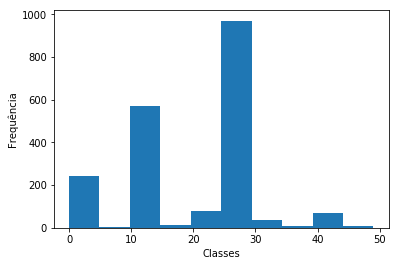

```python
dataset['K-classes'].plot(kind='hist')
plt.xlabel('Classes')
plt.ylabel('Frequência')
```

```python
class_instances.loc[class_instances["Nº Instancias"] > 10]
```

|  | Classe | Nº Instancias |
| --- | --- | --- |
| 0 | 0 | 238 |
| 14 | 14 | 568 |
| 21 | 21 | 72 |
| 25 | 25 | 11 |
| 28 | 28 | 952 |
| 31 | 31 | 31 |
| 40 | 40 | 35 |
| 43 | 43 | 27 |

## K-means com K = 50, max_iter = 10

```python
from sklearn.cluster import KMeans
kmeans = KMeans(n_clusters=50, max_iter=10, random_state=0).fit(X)
```

```python
a = np.array(kmeans.labels_)
```

```python
unique, counts = np.unique(a, return_counts=True)
dicionario = dict(zip(unique, counts))
print(dicionario)
lista = list(dicionario.items())
class_instances = pd.DataFrame(lista, columns=["Classe", "Nº Instancias"])
class_instances
```

```
{0: 207, 1: 1, 2: 1, 3: 1, 4: 1, 5: 1, 6: 1, 7: 1, 8: 1, 9: 1, 10: 1, 11: 1, 12: 1, 13: 1, 14: 596, 15: 2, 16: 1, 17: 6, 18: 1, 19: 1, 20: 2, 21: 83, 22: 1, 23: 1, 24: 1, 25: 11, 26: 4, 27: 2, 28: 945, 29: 1, 30: 1, 31: 31, 32: 1, 33: 2, 34: 3, 35: 1, 36: 1, 37: 1, 38: 2, 39: 3, 40: 35, 41: 2, 42: 2…
```

|  | Classe | Nº Instancias |
| --- | --- | --- |
| 0 | 0 | 207 |
| 1 | 1 | 1 |
| 2 | 2 | 1 |
| 3 | 3 | 1 |
| 4 | 4 | 1 |
| 5 | 5 | 1 |
| 6 | 6 | 1 |
| 7 | 7 | 1 |
| 8 | 8 | 1 |
| 9 | 9 | 1 |
| 10 | 10 | 1 |
| 11 | 11 | 1 |
| 12 | 12 | 1 |
| 13 | 13 | 1 |
| 14 | 14 | 596 |
| 15 | 15 | 2 |
| 16 | 16 | 1 |
| 17 | 17 | 6 |
| 18 | 18 | 1 |
| 19 | 19 | 1 |
| 20 | 20 | 2 |
| 21 | 21 | 83 |
| 22 | 22 | 1 |
| 23 | 23 | 1 |
| 24 | 24 | 1 |
| 25 | 25 | 11 |
| 26 | 26 | 4 |
| 27 | 27 | 2 |
| 28 | 28 | 945 |
| 29 | 29 | 1 |
| 30 | 30 | 1 |
| 31 | 31 | 31 |
| 32 | 32 | 1 |
| 33 | 33 | 2 |
| 34 | 34 | 3 |
| 35 | 35 | 1 |
| 36 | 36 | 1 |
| 37 | 37 | 1 |
| 38 | 38 | 2 |
| 39 | 39 | 3 |
| 40 | 40 | 35 |
| 41 | 41 | 2 |
| 42 | 42 | 2 |
| 43 | 43 | 26 |
| 44 | 44 | 1 |
| 45 | 45 | 2 |
| 46 | 46 | 5 |
| 47 | 47 | 1 |
| 48 | 48 | 1 |
| 49 | 49 | 1 |

### Adicionando a coluna calculada `kmeans.label_` ao conjunto de dados

```python
dataset["K-classes"] = kmeans.labels_
```

```
Text(0,0.5,'Frequência')
```

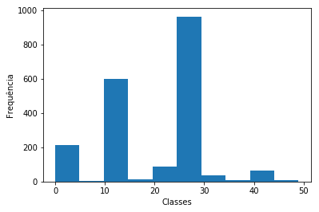

```python
dataset['K-classes'].plot(kind='hist')
plt.xlabel('Classes')
plt.ylabel('Frequência')
```

```python
class_instances.loc[class_instances["Nº Instancias"] > 10]
```

|  | Classe | Nº Instancias |
| --- | --- | --- |
| 0 | 0 | 207 |
| 14 | 14 | 596 |
| 21 | 21 | 83 |
| 25 | 25 | 11 |
| 28 | 28 | 945 |
| 31 | 31 | 31 |
| 40 | 40 | 35 |
| 43 | 43 | 26 |

## K-means com K = 50, max_iter = 100

```python
from sklearn.cluster import KMeans
kmeans = KMeans(n_clusters=50, max_iter=100, random_state=0).fit(X)
y_kmeans = kmeans.fit_predict(X)
```

```python
a = np.array(kmeans.labels_)
```

```python
unique, counts = np.unique(a, return_counts=True)
dicionario = dict(zip(unique, counts))
print(dicionario)
lista = list(dicionario.items())
class_instances = pd.DataFrame(lista, columns=["Classe", "Nº Instancias"])
class_instances
```

```
{0: 207, 1: 1, 2: 1, 3: 1, 4: 1, 5: 1, 6: 1, 7: 1, 8: 1, 9: 1, 10: 1, 11: 1, 12: 1, 13: 1, 14: 596, 15: 2, 16: 1, 17: 6, 18: 1, 19: 1, 20: 2, 21: 83, 22: 1, 23: 1, 24: 1, 25: 11, 26: 4, 27: 2, 28: 945, 29: 1, 30: 1, 31: 31, 32: 1, 33: 2, 34: 3, 35: 1, 36: 1, 37: 1, 38: 2, 39: 3, 40: 35, 41: 2, 42: 2…
```

|  | Classe | Nº Instancias |
| --- | --- | --- |
| 0 | 0 | 207 |
| 1 | 1 | 1 |
| 2 | 2 | 1 |
| 3 | 3 | 1 |
| 4 | 4 | 1 |
| 5 | 5 | 1 |
| 6 | 6 | 1 |
| 7 | 7 | 1 |
| 8 | 8 | 1 |
| 9 | 9 | 1 |
| 10 | 10 | 1 |
| 11 | 11 | 1 |
| 12 | 12 | 1 |
| 13 | 13 | 1 |
| 14 | 14 | 596 |
| 15 | 15 | 2 |
| 16 | 16 | 1 |
| 17 | 17 | 6 |
| 18 | 18 | 1 |
| 19 | 19 | 1 |
| 20 | 20 | 2 |
| 21 | 21 | 83 |
| 22 | 22 | 1 |
| 23 | 23 | 1 |
| 24 | 24 | 1 |
| 25 | 25 | 11 |
| 26 | 26 | 4 |
| 27 | 27 | 2 |
| 28 | 28 | 945 |
| 29 | 29 | 1 |
| 30 | 30 | 1 |
| 31 | 31 | 31 |
| 32 | 32 | 1 |
| 33 | 33 | 2 |
| 34 | 34 | 3 |
| 35 | 35 | 1 |
| 36 | 36 | 1 |
| 37 | 37 | 1 |
| 38 | 38 | 2 |
| 39 | 39 | 3 |
| 40 | 40 | 35 |
| 41 | 41 | 2 |
| 42 | 42 | 2 |
| 43 | 43 | 26 |
| 44 | 44 | 1 |
| 45 | 45 | 2 |
| 46 | 46 | 5 |
| 47 | 47 | 1 |
| 48 | 48 | 1 |
| 49 | 49 | 1 |

### Adicionando a coluna calculada `kmeans.label_` ao conjunto de dados

```python
dataset["K-classes"] = kmeans.labels_
```

```
Text(0,0.5,'Frequência')
```

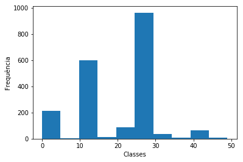

```python
dataset['K-classes'].plot(kind='hist')
plt.xlabel('Classes')
plt.ylabel('Frequência')
```

```python
class_instances.loc[class_instances["Nº Instancias"] > 10]
```

|  | Classe | Nº Instancias |
| --- | --- | --- |
| 0 | 0 | 207 |
| 14 | 14 | 596 |
| 21 | 21 | 83 |
| 25 | 25 | 11 |
| 28 | 28 | 945 |
| 31 | 31 | 31 |
| 40 | 40 | 35 |
| 43 | 43 | 26 |

# 2.2. Alterar o parâmetro linkage do Hierárquico

Linkage : {“ward”, “complete”, “average”, “single”}, optional (default=”ward”) Which linkage criterion to use. The linkage criterion determines which distance to use between sets of observation. The algorithm will merge the pairs of cluster that minimize this criterion.

ward minimizes the variance of the clusters being merged. average uses the average of the distances of each observation of the two sets. complete or maximum linkage uses the maximum distances between all observations of the two sets. single uses the minimum of the distances between all observations of the two sets.

Referência: http://scikit-learn.org/stable/modules/generated/sklearn.cluster.AgglomerativeClustering.html

## Hierárquico, K = 100

```python
from sklearn.cluster import AgglomerativeClustering
clustering = AgglomerativeClustering(n_clusters=100, affinity='euclidean', linkage="average").fit(X)
```

```python
a = np.array(clustering.labels_)
```

```python
unique, counts = np.unique(a, return_counts=True)
dicionario = dict(zip(unique, counts))
print(dicionario)
lista = list(dicionario.items())
class_instances = pd.DataFrame(lista, columns=["Classe", "Nº Instancias"])
class_instances
```

```
{0: 1824, 1: 21, 2: 2, 3: 6, 4: 16, 5: 3, 6: 4, 7: 1, 8: 3, 9: 2, 10: 2, 11: 3, 12: 2, 13: 1, 14: 4, 15: 1, 16: 1, 17: 1, 18: 1, 19: 1, 20: 5, 21: 1, 22: 1, 23: 3, 24: 2, 25: 1, 26: 1, 27: 1, 28: 1, 29: 1, 30: 1, 31: 1, 32: 1, 33: 1, 34: 1, 35: 1, 36: 1, 37: 1, 38: 1, 39: 1, 40: 1, 41: 1, 42: 1, 43:…
```

|  | Classe | Nº Instancias |
| --- | --- | --- |
| 0 | 0 | 1824 |
| 1 | 1 | 21 |
| 2 | 2 | 2 |
| 3 | 3 | 6 |
| 4 | 4 | 16 |
| 5 | 5 | 3 |
| 6 | 6 | 4 |
| 7 | 7 | 1 |
| 8 | 8 | 3 |
| 9 | 9 | 2 |
| 10 | 10 | 2 |
| 11 | 11 | 3 |
| 12 | 12 | 2 |
| 13 | 13 | 1 |
| 14 | 14 | 4 |
| 15 | 15 | 1 |
| 16 | 16 | 1 |
| 17 | 17 | 1 |
| 18 | 18 | 1 |
| 19 | 19 | 1 |
| 20 | 20 | 5 |
| 21 | 21 | 1 |
| 22 | 22 | 1 |
| 23 | 23 | 3 |
| 24 | 24 | 2 |
| 25 | 25 | 1 |
| 26 | 26 | 1 |
| 27 | 27 | 1 |
| 28 | 28 | 1 |
| 29 | 29 | 1 |
| ... | ... | ... |
| 70 | 70 | 1 |
| 71 | 71 | 1 |
| 72 | 72 | 1 |
| 73 | 73 | 1 |
| 74 | 74 | 1 |
| 75 | 75 | 1 |
| 76 | 76 | 1 |
| 77 | 77 | 1 |
| 78 | 78 | 1 |
| 79 | 79 | 1 |
| 80 | 80 | 1 |
| 81 | 81 | 1 |
| 82 | 82 | 1 |
| 83 | 83 | 1 |
| 84 | 84 | 1 |
| 85 | 85 | 1 |
| 86 | 86 | 1 |
| 87 | 87 | 1 |
| 88 | 88 | 1 |
| 89 | 89 | 1 |
| 90 | 90 | 1 |
| 91 | 91 | 1 |
| 92 | 92 | 1 |
| 93 | 93 | 1 |
| 94 | 94 | 1 |
| 95 | 95 | 1 |
| 96 | 96 | 1 |
| 97 | 97 | 1 |
| 98 | 98 | 9 |
| 99 | 99 | 1 |

100 rows × 2 columns

```python
class_instances.loc[class_instances["Nº Instancias"] > 10]
```

|  | Classe | Nº Instancias |
| --- | --- | --- |
| 0 | 0 | 1824 |
| 1 | 1 | 21 |
| 4 | 4 | 16 |

```python
dataset['K-classes-hierar'] = clustering.labels_
```

```python
dataset.describe()
```

|  | adipose_tissue | adrenal_gland | animal_ovary | appendix | bladder | bone_marrow | cerebral_cortex | colon | duodenum | endometrium | esophagus | fallopian_tube | gallbladder | heart | kidney | liver | lung | lymph_node | pancreas | placenta | prostate | rectum | salivary_gland | skeletal_muscle | skin | small_intestine | smooth_muscle | spleen | stomach | … |
| --- | --- | --- | --- | --- | --- | --- | --- | --- | --- | --- | --- | --- | --- | --- | --- | --- | --- | --- | --- | --- | --- | --- | --- | --- | --- | --- | --- | --- | --- | --- |
| count | 2000.000000 | 2000.000000 | 2000.000000 | 2000.000000 | 2000.000000 | 2000.000000 | 2000.000000 | 2000.000000 | 2000.000000 | 2000.000000 | 2000.000000 | 2000.000000 | 2000.000000 | 2000.000000 | 2000.000000 | 2000.000000 | 2000.000000 | 2000.000000 | 2000.000000 | 2000.000000 | 2000.000000 | 2000.000000 | 2000.000000 | 2000.000000 | 2000.000000 | 2000.000000 | 2000.000000 | 2000.000000 | 2000.000000 | … |
| mean | 39.040157 | 41.486336 | 51.338392 | 52.555181 | 48.932735 | 53.852077 | 45.797667 | 40.663197 | 39.632611 | 52.066032 | 41.493874 | 53.691974 | 57.023709 | 21.915492 | 27.728612 | 35.790131 | 54.864549 | 54.294117 | 35.087462 | 52.105545 | 46.389605 | 42.376928 | 27.628763 | 22.053380 | 35.257338 | 43.396844 | 52.185982 | 56.164531 | 37.587312 | … |
| std | 195.264717 | 181.466441 | 210.726346 | 252.295704 | 221.732356 | 393.758129 | 123.183344 | 157.028175 | 185.991398 | 186.169270 | 139.247221 | 261.725555 | 314.203534 | 116.726607 | 136.411996 | 336.523288 | 277.654367 | 277.993904 | 1108.114405 | 242.242244 | 241.613858 | 165.470468 | 308.543568 | 208.651352 | 95.223057 | 193.638153 | 233.848790 | 347.561819 | 207.009834 | … |
| min | 0.000003 | 0.000003 | 0.000004 | 0.000004 | 0.000004 | 0.000003 | 0.000004 | 0.000003 | 0.000003 | 0.000004 | 0.000004 | 0.000004 | 0.000004 | 0.000002 | 0.000002 | 0.000003 | 0.000004 | 0.000004 | 0.000002 | 0.000004 | 0.000004 | 0.000003 | 0.000003 | 0.000002 | 0.000003 | 0.000003 | 0.000004 | 0.000004 | 0.000003 | … |
| 25% | 3.173068 | 3.105311 | 3.140023 | 7.117802 | 7.087438 | 1.257345 | 7.631545 | 3.071134 | 2.765053 | 7.428423 | 3.506638 | 7.896982 | 8.147757 | 1.569051 | 2.492157 | 1.170095 | 7.812597 | 3.751913 | 0.602562 | 4.128284 | 7.150531 | 3.094211 | 2.414023 | 0.427236 | 3.304699 | 5.983976 | 4.248427 | 3.678518 | 5.874027 | … |
| 50% | 12.692271 | 15.526556 | 19.625143 | 21.353406 | 21.262314 | 9.430086 | 19.078863 | 15.355670 | 13.825265 | 21.224067 | 14.026553 | 23.690945 | 20.369393 | 6.724503 | 9.968628 | 5.850474 | 23.437791 | 18.759564 | 2.008539 | 20.641418 | 17.876327 | 15.471057 | 8.046744 | 2.136179 | 16.523495 | 14.959941 | 21.242137 | 22.071107 | 14.685068 | … |
| 75% | 31.730678 | 34.158423 | 43.175314 | 46.265713 | 42.524627 | 34.576981 | 41.973499 | 33.782474 | 30.415583 | 50.937760 | 35.066382 | 47.381890 | 48.886544 | 15.690507 | 24.921571 | 17.551423 | 46.875582 | 48.774865 | 6.025616 | 45.411120 | 42.903184 | 34.036326 | 18.775735 | 8.544717 | 36.351689 | 32.911870 | 42.484273 | 47.820732 | 29.370135 | … |
| max | 7377.382624 | 5216.922745 | 4827.785071 | 7644.519332 | 7548.121360 | 12623.741610 | 2663.409328 | 3528.732999 | 5275.721159 | 6460.605882 | 3857.301972 | 9733.029992 | 12201.266550 | 4512.141526 | 5587.416115 | 13058.258680 | 9707.151804 | 7931.543465 | 48970.179710 | 9032.684565 | 9585.286431 | 3945.119614 | 13529.258260 | 7732.968610 | 1939.858329 | 5032.524122 | 8322.669088 | 12036.110500 | 7486.447452 | … |

```
Text(0,0.5,'Frequência')
```

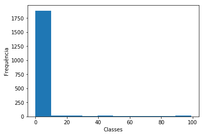

```python
dataset['K-classes-hierar'].plot(kind='hist')
plt.xlabel('Classes')
plt.ylabel('Frequência')
```